# H6

Dominik Pegler

Deadline: Sunday, 1st May 2022, 11:59pm

## 1. Create a dataset …

… that contains three variables: variable “subject_ID” shall contain the numbers from 1 to 40 in a chronological order. Variables “rating_1” and “rating_2” shall contain rating responses from a 7-point Likert scale (think about what this means for the probable ditribution of the data…).

(1 Point)

```r
N <- 40

subject_ID <- seq(1:N)

# for a 7-point likert scale, we assume normal distribution
# which we simulate with the following probability distribution

likert_7 = 1:7

# prob_7_likert <- c(1/7, 1/7, 1/7, 1/7, 1/7, 1/7, 1/7) # uniform
prob_likert_7 <- c(0.25/7, 0.5/7, 1.5/7, 2.5/7, 1.5/7, 0.5/7, 0.25/7) # normal

rating_1 <- sample(likert_7, N, replace = TRUE, prob = prob_likert_7)
rating_2 <- sample(likert_7, N, replace = TRUE, prob = prob_likert_7)

# creating the dataframe
df <- data.frame(subject_ID)
df$rating_1 <- factor(rating_1, order=TRUE, levels = likert_7)
df$rating_2 <- factor(rating_2, order=TRUE, levels = likert_7)
head(df)
```

|  | subject_ID | rating_1 | rating_2 |
| --- | --- | --- | --- |
| 1 | 1 | 4 | 4 |
| 2 | 2 | 5 | 3 |
| 3 | 3 | 3 | 2 |
| 4 | 4 | 4 | 3 |
| 5 | 5 | 4 | 4 |
| 6 | 6 | 4 | 4 |

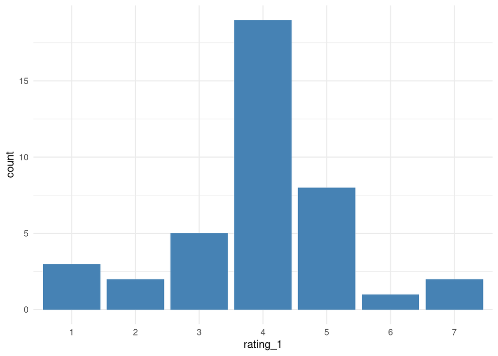

```r
# import ggplot and set some defaults
library(ggplot2)
theme_set(theme_minimal())
update_geom_defaults("bar", list(fill = "steelblue"))

ggplot(df, aes(x=rating_1)) +
  scale_x_discrete(drop=FALSE) +
  geom_bar()
```

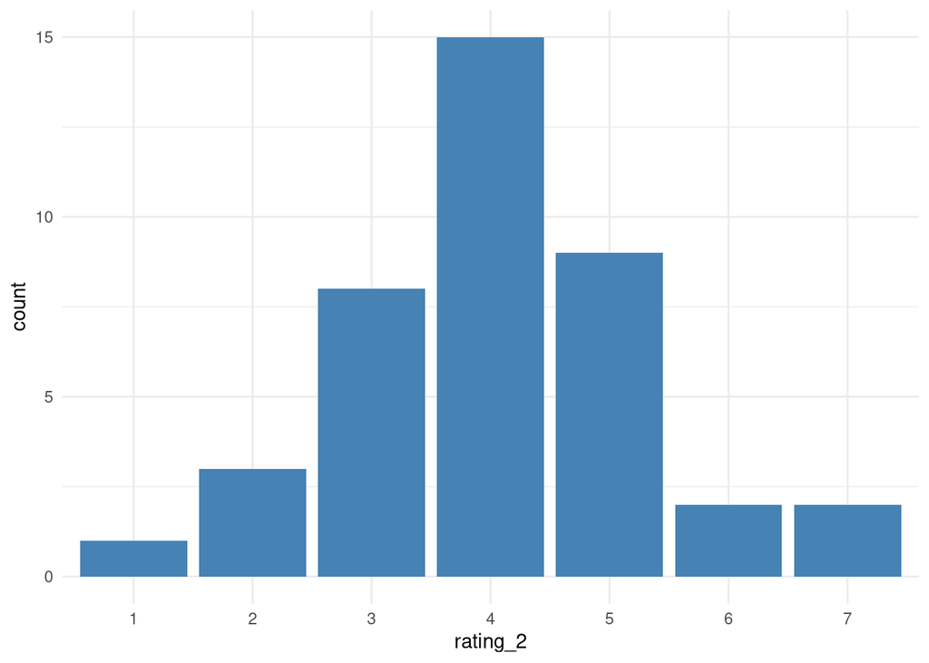

```r
ggplot(df, aes(x=rating_2)) +
  scale_x_discrete(drop=FALSE) +
  geom_bar()
```

## 2. Create another variable …

… (“level”) based on the two rating variables. The variable should be a string variable and should contain the value “1 higher” when rating_1 is higher than rating_2, it should contain the value “2 higher” when rating_2 is higher than rating_1, and it should contain the value “equal” when both ratings contain the same value.

(1 Point)

```r
df$level = "equal" # inital value for all rows
df[df$rating_1 > df$rating_2, "level"] <- "1 higher"
df[df$rating_1 < df$rating_2, "level"] <- "2 higher"
head(df)
```

|  | subject_ID | rating_1 | rating_2 | level |
| --- | --- | --- | --- | --- |
| 1 | 1 | 4 | 4 | equal |
| 2 | 2 | 5 | 3 | 1 higher |
| 3 | 3 | 3 | 2 | 1 higher |
| 4 | 4 | 4 | 3 | 1 higher |
| 5 | 5 | 4 | 4 | equal |
| 6 | 6 | 4 | 4 | equal |

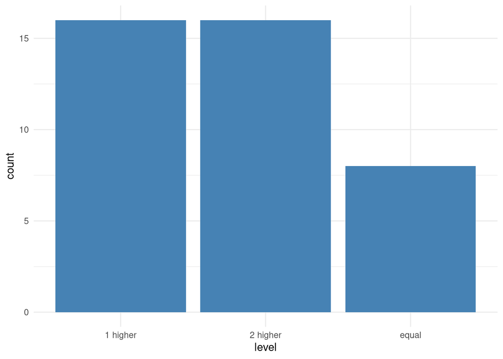

```r
ggplot(df, aes(x=level)) +
  scale_x_discrete(drop=FALSE) +
  geom_bar()
```

## 3. Calculate …

… the value z from the values x and y with this formula: z = x/y. To do this calculation, you need to specify some traits for x and y. Tipp: which class is need to calculate sth? What does basic mathematic tell us about divisions? What is not possible? Put all these requirements in an if statement so that R will only conduct the calculation if these requirements are met. R should also tell you when it couldn’t do the calculation! Give two examples: one, where R will calculate and one, where R will not calculate.

(2 Points)

```r
# create some random x and y values with y based on the level variable (just to make some use of it :) )

# x: random int values between 0 and 5 and a few missing values

df$x <- sample(-1:5,N, replace = TRUE)
df[df$x == -1, "x"] <- NA

# y

# these ones will get a problematic 0 as divisor
df[df$level == "2 higher", "y"] <- 0
# these ones will get a useful divisor (int between 1 and 5)
df[df$level == "1 higher", "y"] <- sample(1:5, length(df[df$level == "1 higher", "y"]), replace=TRUE)
# all the others with level == "equal" will have problematic missing values

head(df)
```

|  | subject_ID | rating_1 | rating_2 | level | x | y |
| --- | --- | --- | --- | --- | --- | --- |
| 1 | 1 | 4 | 4 | equal | 5 | NA |
| 2 | 2 | 5 | 3 | 1 higher | 0 | 4 |
| 3 | 3 | 3 | 2 | 1 higher | NA | 2 |
| 4 | 4 | 4 | 3 | 1 higher | 0 | 2 |
| 5 | 5 | 4 | 4 | equal | 2 | NA |
| 6 | 6 | 4 | 4 | equal | 1 | NA |

```r
for (i in 1:nrow(df)) {
  x_ = df[i,"x"]
  y_ = df[i,"y"]

  cat("Row",i,"\tx:",x_,"\ty:",y_,"\t")

  if (is.na(x_) | is.na(y_)) {
    cat("z: - \tMissing value(s)")
  } else if (y_ == 0) {
    cat("z: - \tDivision by 0")
  } else {cat("z:",x_/y_)}

  cat("\n")
}
```

```
## Row 1    x: 5    y: NA   z: -    Missing value(s)
## Row 2    x: 0    y: 4    z: 0
## Row 3    x: NA   y: 2    z: -    Missing value(s)
## Row 4    x: 0    y: 2    z: 0
## Row 5    x: 2    y: NA   z: -    Missing value(s)
## Row 6    x: 1    y: NA   z: -    Missing value(s)
## Row 7    x: NA   y: NA   z: -    Missing value(s)
## Row 8    x: 5    y: 5    z: 1
## Row 9    x: 1    y: 5    z: 0.2
## Row 10   x: 1    y: 0    z: -    Division by 0
## Row 11   x: 2    y: 0    z: -    Division by 0
## Row 12   x: 1    y: 5    z: 0.2
## Row 13   x: NA   y: 0    z: -    Missing value(s)
## Row 14   x: 2    y: 0    z: -    Division by 0
## Row 15   x: 1    y: 2    z: 0.5
## Row 16   x: 4    y: 0    z: -    Division by 0
## Row 17   x: 1    y: 3    z: 0.3333333
## Row 18   x: 2    y: NA   z: -    Missing value(s)
## Row 19   x: 1    y: 5    z: 0.2
## Row 20   x: 4    y: NA   z: -    Missing value(s)
## Row 21   x: 4    y: 0    z: -    Division by 0
## Row 22   x: 0    y: 3    z: 0
## Row 23   x: 4    y: 0    z: -    Division by 0
## Row 24   x: 5    y: 0    z: -    Division by 0
## Row 25   x: NA   y: NA   z: -    Missing value(s)
## Row 26   x: 2    y: 0    z: -    Division by 0
## Row 27   x: 4    y: 0    z: -    Division by 0
## Row 28   x: 2    y: 5    z: 0.4
## Row 29   x: 0    y: 0    z: -    Division by 0
## Row 30   x: 0    y: 0    z: -    Division by 0
## Row 31   x: 1    y: 4    z: 0.25
## Row 32   x: 0    y: 0    z: -    Division by 0
## Row 33   x: 4    y: 3    z: 1.333333
## Row 34   x: 3    y: 0    z: -    Division by 0
## Row 35   x: 5    y: 3    z: 1.666667
## Row 36   x: 5    y: 3    z: 1.666667
## Row 37   x: 3    y: 0    z: -    Division by 0
## Row 38   x: 0    y: 4    z: 0
## Row 39   x: 5    y: 0    z: -    Division by 0
## Row 40   x: 4    y: NA   z: -    Missing value(s)
```

```r
# when we create the column z, we get all possible results, for the
# problematic cases R will give us 'Inf' (div by 0), NA (missing
# values) and 'NaN' (0 div by 0)

df$z <- df$x / df$y
head(df)
```

|  | subject_ID | rating_1 | rating_2 | level | x | y | z |
| --- | --- | --- | --- | --- | --- | --- | --- |
| 1 | 1 | 4 | 4 | equal | 5 | NA | NA |
| 2 | 2 | 5 | 3 | 1 higher | 0 | 4 | 0 |
| 3 | 3 | 3 | 2 | 1 higher | NA | 2 | NA |
| 4 | 4 | 4 | 3 | 1 higher | 0 | 2 | 0 |
| 5 | 5 | 4 | 4 | equal | 2 | NA | NA |
| 6 | 6 | 4 | 4 | equal | 1 | NA | NA |

## 4. Use a for loop …

… to calculate the sum of rating_1 and rating_2 for each subject_ID and save it in a new column “rating_sum”.

(1 Point)

```r
for (i in 1:nrow(df)) {

  # includes the necessary conversion back to integers since rating_1 and rating_2
  # are ordered factors
  df[i,"rating_sum"] = as.numeric(df[i,"rating_1"]) + as.numeric(df[i,"rating_2"])

}

head(df)
```

|  | subject_ID | rating_1 | rating_2 | level | x | y | z | rating_sum |
| --- | --- | --- | --- | --- | --- | --- | --- | --- |
| 1 | 1 | 4 | 4 | equal | 5 | NA | NA | 8 |
| 2 | 2 | 5 | 3 | 1 higher | 0 | 4 | 0 | 8 |
| 3 | 3 | 3 | 2 | 1 higher | NA | 2 | NA | 5 |
| 4 | 4 | 4 | 3 | 1 higher | 0 | 2 | 0 | 7 |
| 5 | 5 | 4 | 4 | equal | 2 | NA | NA | 8 |
| 6 | 6 | 4 | 4 | equal | 1 | NA | NA | 8 |

## 5. Tell …

… why is the approach in exercise 4 not the best? What would have been a better solution to calculate the variable? Explain and give alternative calculation.

(1 Point)

Answer:

I would assume that for-loops in R are slow and you have to handle the exceptions (division by zero, missing values) yourself, as opposed to built-in, already optimized (c/c++ under the hood?) vector functions with standard behaviour for exceptions.

```r
df$rating_sum_v <- as.numeric(df$rating_1) + as.numeric(df$rating_2)
head(df)
```

|  | subject_ID | rating_1 | rating_2 | level | x | y | z | rating_sum | rating_sum_v |
| --- | --- | --- | --- | --- | --- | --- | --- | --- | --- |
| 1 | 1 | 4 | 4 | equal | 5 | NA | NA | 8 | 8 |
| 2 | 2 | 5 | 3 | 1 higher | 0 | 4 | 0 | 8 | 8 |
| 3 | 3 | 3 | 2 | 1 higher | NA | 2 | NA | 5 | 5 |
| 4 | 4 | 4 | 3 | 1 higher | 0 | 2 | 0 | 7 | 7 |
| 5 | 5 | 4 | 4 | equal | 2 | NA | NA | 8 | 8 |
| 6 | 6 | 4 | 4 | equal | 1 | NA | NA | 8 | 8 |